# Movement Analysis II

Author

Lejla Beganovic

# Introduction

In the previous task, transportation mode was predicted using only movement parameters derived from the GPS trajectories themselves (speed, acceleration, sinuosity, turning angle). This task extends that approach by incorporating geographic context data from OpenStreetMap (OSM). The idea is that knowing what kind of road or railway a GPS point is near can help the model distinguish between modes that have similar movement signatures, such as bus and car.

The context data includes road type (`highway`), cycling infrastructure (`cycleway`), and railway type (`railway`). Several additional distance-based features are added on top of the examples shown in the getting started guide.

# Step 1: Load the Data

```r
library(sf)
library(dplyr)

# Paths
pfad_I  <- "C:/Users/Lejlum/movement_analysis_I/Movement Analysis I-20260501"
pfad_II <- "C:/Users/Lejlum/movement_analysis_II"

# Load OSM context data
highway <- read_sf(file.path(pfad_II, "osm.gpkg"), layer = "highway")
railway <- read_sf(file.path(pfad_II, "osm.gpkg"), layer = "railway")

# Load GPS movement data
training_dataset <- read_sf(file.path(pfad_I, "tracks_1.gpkg"), layer = "training") |>
  mutate(data = "training")
testing_dataset  <- read_sf(file.path(pfad_I, "tracks_1.gpkg"), layer = "testing")  |>
  mutate(data = "testing")
validation_dataset <- read_sf(file.path(pfad_I, "tracks_1.gpkg"), layer = "validation") |>
  mutate(data = "validation")

full_dataset <- bind_rows(training_dataset, testing_dataset, validation_dataset)

cat("GPS points:", nrow(full_dataset), "\n")
```

```
GPS points: 1004732
```

```r
cat("Highway segments:", nrow(highway), "\n")
```

```
Highway segments: 43376
```

```r
cat("Railway segments:", nrow(railway), "\n")
```

```
Railway segments: 4095
```

## Visualize the OSM Context Data

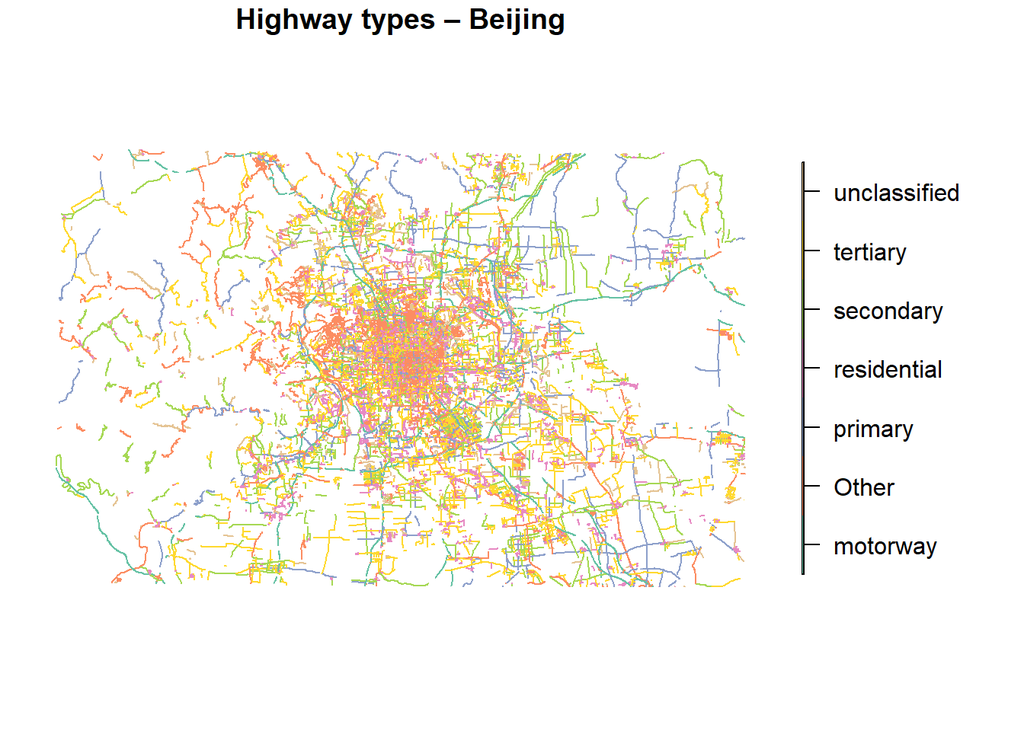

```r
plot(highway["highway"], main = "Highway types – Beijing")
```

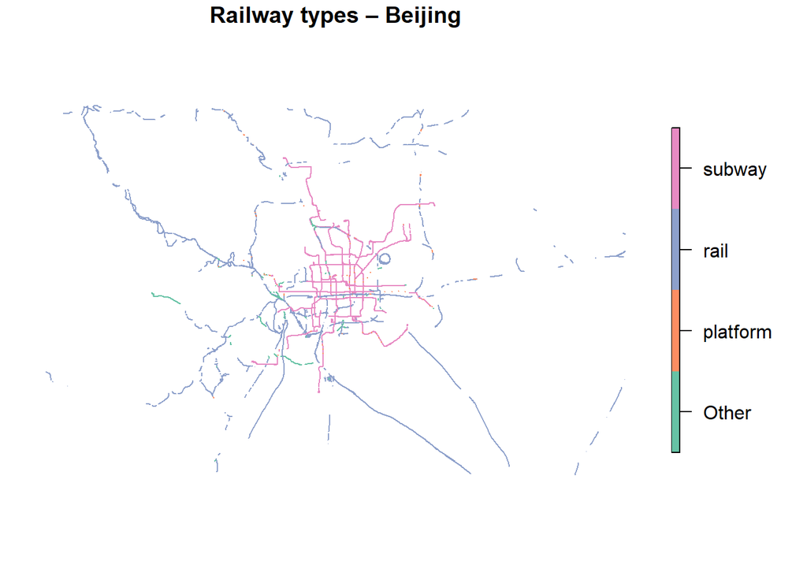

```r
plot(railway["railway"], main = "Railway types – Beijing")
```

The highway layer contains 43,376 road segments covering all major road types in Beijing, from motorways to residential streets. The railway layer contains 4,095 segments, clearly showing the Beijing subway network concentrated in the city centre and several overground rail lines extending outwards.

# Step 2: Feature Engineering

## Movement Features (from the previous task)

The same movement features as in the previous task are computed: step length, time lag, speed, acceleration, sinuosity over a 5-point window, and turning angle.

```r
library(zoo)

# Speed and steplength
full_dataset <- full_dataset |>
  mutate(
    steplength = as.numeric(st_distance(lead(geom), geom, by_element = TRUE)),
    timelag    = as.numeric(difftime(lead(datetime), datetime, units = "secs")),
    speed      = steplength / timelag,
    .by = track_id
  )

# Acceleration
full_dataset <- full_dataset |>
  mutate(
    acceleration = (lead(speed) - speed) / timelag,
    .by = track_id
  )

# Sinuosity (5-point window)
full_dataset <- full_dataset |>
  mutate(
    straight_dist5 = as.numeric(st_distance(lead(geom, 5), geom, by_element = TRUE)),
    full_dist5     = rollsum(steplength, 5, fill = NA, align = "left"),
    sinuosity      = full_dist5 / straight_dist5,
    .by = track_id
  )

# Turning angle
full_dataset <- full_dataset |>
  mutate(
    dx = as.numeric(lead(st_coordinates(geom)[, 1]) - st_coordinates(geom)[, 1]),
    dy = as.numeric(lead(st_coordinates(geom)[, 2]) - st_coordinates(geom)[, 2]),
    .by = track_id
  ) |>
  mutate(
    azi_next   = atan2(dy, dx),
    azi_prev   = lag(azi_next),
    turn_angle = atan2(sin(azi_next - azi_prev), cos(azi_next - azi_prev)),
    .by = track_id
  )
```

## Context Features (new this task)

### Highway Type and Cycleway

The nearest highway segment is joined to each GPS point using `st_nearest_feature`. This gives the road type (`highway`) and whether the road has cycling infrastructure (`cycleway`).

```r
full_dataset <- st_join(full_dataset, highway |> select(highway, cycleway),
                        join = st_nearest_feature)
```

### Distance to Nearest Railway

```r
nearest_rail <- st_nearest_feature(full_dataset, railway)
full_dataset$distance_to_railway <- as.numeric(
  st_distance(full_dataset, railway[nearest_rail, ], by_element = TRUE)
)
```

### Additional Features

Three extra context features are added beyond the examples shown in the getting started guide.

**1. Railway type of the nearest line.** Distinguishing subway from overground rail helps the model separate subway and train predictions, since they follow spatially distinct corridors in Beijing.

```r
full_dataset$railway_type <- railway$railway[nearest_rail]
```

**2. Near railway (binary).** A point within 50 m of a railway line is likely on a train or subway. This binary threshold feature is easier for the model to use than a raw distance value.

```r
full_dataset$near_railway <- as.numeric(full_dataset$distance_to_railway < 50)
```

**3. Distance to nearest motorway.** Motorways are used only by cars and buses, not cyclists or pedestrians. Points very close to a motorway are very unlikely to be walking or cycling, which helps the model rule out those modes.

```r
motorway <- highway |> filter(highway == "motorway")

nearest_mw <- st_nearest_feature(full_dataset, motorway)
full_dataset$distance_to_motorway <- as.numeric(
  st_distance(full_dataset, motorway[nearest_mw, ], by_element = TRUE)
)
```

# Step 3: Prepare Training Data

All movement and context features are combined. The `highway` and `railway_type` columns are converted to factors. Rows with missing values at segment boundaries are removed.

```r
feat_cols <- c("speed", "acceleration", "sinuosity", "turn_angle",
               "highway", "cycleway", "distance_to_railway",
               "railway_type", "near_railway", "distance_to_motorway")

point_data <- full_dataset |>
  st_drop_geometry() |>
  select(data, mode, all_of(feat_cols)) |>
  mutate(
    highway      = factor(highway),
    railway_type = factor(railway_type),
    cycleway     = as.numeric(cycleway)
  ) |>
  filter(if_all(c("speed", "acceleration", "sinuosity", "turn_angle",
                  "distance_to_railway", "near_railway",
                  "distance_to_motorway"), ~ is.finite(.))) |>
  filter(!is.na(highway), !is.na(railway_type))

point_train <- point_data |>
  filter(data == "training", !is.na(mode)) |>
  select(-data) |>
  mutate(mode = factor(mode))

point_test <- point_data |>
  filter(data == "testing", !is.na(mode)) |>
  select(-data) |>
  mutate(mode = factor(mode))

cat("Training points:", nrow(point_train), "\n")
```

```
Training points: 398342
```

```r
cat("Testing points:", nrow(point_test), "\n")
```

```
Testing points: 214793
```

```r
cat("Class distribution:\n")
```

```
Class distribution:
```

```r
print(table(point_train$mode))
```

```
  bike    bus    car subway  train   walk
 75311 123943  50791  17274   3014 128009
```

# Step 4: Train the Model

A Random Forest is trained on all movement and context features combined. The same downsampling approach as in the previous task is used to keep training time manageable.

```r
library(ranger)

set.seed(42)

point_sample <- point_train |>
  group_by(mode) |>
  slice_sample(n = 8000, replace = TRUE) |>
  ungroup()

rf_context <- ranger(
  formula = mode ~ speed + acceleration + sinuosity + turn_angle +
                   highway + cycleway + distance_to_railway +
                   railway_type + near_railway + distance_to_motorway,
  data           = point_sample,
  num.trees      = 300,
  importance     = "impurity",
  classification = TRUE,
  seed           = 42
)

print(rf_context)
```

```
Ranger result

Call:
 ranger(formula = mode ~ speed + acceleration + sinuosity + turn_angle +      highway + cycleway + distance_to_railway + railway_type +      near_railway + distance_to_motorway, data = point_sample,      num.trees = 300, importance = "impurity", classification = TRUE,      seed = 42)

Type:                             Classification
Number of trees:                  300
Sample size:                      48000
Number of independent variables:  10
Mtry:                             3
Target node size:                 1
Variable importance mode:         impurity
Splitrule:                        gini
OOB prediction error:             16.61 %
```

# Step 5: Evaluate the Model

```r
library(caret)

pred_context <- predict(rf_context, data = point_test)$predictions

pred_context    <- factor(pred_context,    levels = sort(levels(point_test$mode)))
point_test$mode <- factor(point_test$mode, levels = sort(levels(point_test$mode)))

confusionMatrix(pred_context, reference = point_test$mode)
```

```
Confusion Matrix and Statistics

          Reference
Prediction  bike   bus   car subway train  walk
    bike   33367  7378  1402    202    27  7485
    bus     3270 37158  8191    430   142  7269
    car      886  9460 16647    321   143  1505
    subway   623  2611  1289  11658   751  1812
    train      2   128   127    161  1907     0
    walk    5230 12592  2345    460    86 37728

Overall Statistics

               Accuracy : 0.6446
                 95% CI : (0.6426, 0.6467)
    No Information Rate : 0.3228
    P-Value [Acc > NIR] : < 2.2e-16

                  Kappa : 0.5404

 Mcnemar's Test P-Value : < 2.2e-16

Statistics by Class:

                     Class: bike Class: bus Class: car Class: subway
Sensitivity               0.7692     0.5360     0.5549       0.88105
Specificity               0.9038     0.8673     0.9334       0.96484
Pos Pred Value            0.6692     0.6581     0.5748       0.62196
Neg Pred Value            0.9393     0.7968     0.9281       0.99197
Prevalence                0.2020     0.3228     0.1397       0.06160
Detection Rate            0.1553     0.1730     0.0775       0.05428
Detection Prevalence      0.2321     0.2629     0.1348       0.08727
Balanced Accuracy         0.8365     0.7016     0.7441       0.92295
                     Class: train Class: walk
Sensitivity              0.624018      0.6761
Specificity              0.998026      0.8697
Pos Pred Value           0.820215      0.6456
Neg Pred Value           0.994592      0.8844
Prevalence               0.014228      0.2598
Detection Rate           0.008878      0.1756
Detection Prevalence     0.010824      0.2721
Balanced Accuracy        0.811022      0.7729
```

The context-enriched model reaches an overall accuracy of **64.5%**, which is a clear improvement over the 50.5% achieved in the previous task with movement features alone. The biggest gain is for subway, whose sensitivity jumped from 0.52 to 0.88. This makes sense: subway lines in Beijing follow fixed, spatially distinct corridors, so proximity to railway infrastructure is a very strong signal. Train also improved, from 0.41 to 0.62. Bike improved from 0.65 to 0.77. Bus and car remain the hardest pair to separate, with sensitivities of 0.54 and 0.55, because both modes use the same road types.

# Step 6: Feature Importance

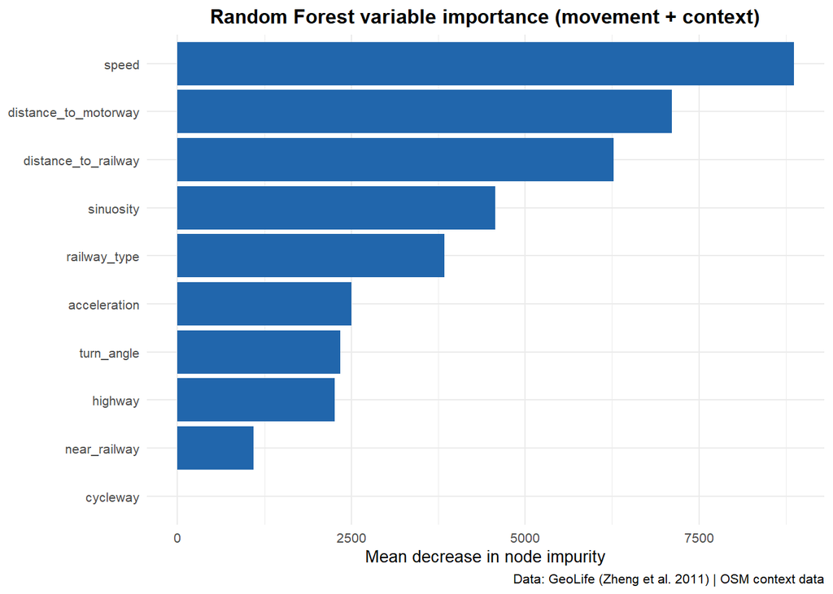

Figure 1: Variable importance from the Random Forest model with movement and context features.

```r
library(ggplot2)

importance_df <- data.frame(
  feature    = names(rf_context$variable.importance),
  importance = rf_context$variable.importance
) |>
  arrange(desc(importance))

ggplot(importance_df, aes(x = reorder(feature, importance), y = importance)) +
  geom_col(fill = "#2166ac") +
  coord_flip() +
  labs(
    title   = "Random Forest variable importance (movement + context)",
    x       = NULL,
    y       = "Mean decrease in node impurity",
    caption = "Data: GeoLife (Zheng et al. 2011) | OSM context data"
  ) +
  theme_minimal(base_size = 10) +
  theme(plot.title = element_text(face = "bold", hjust = 0.5))
```

Figure 1 shows that `speed` remains the most important feature by a large margin. Among the context features, `distance_to_motorway` is the second most important feature overall, ranking above `distance_to_railway` in third place. This is somewhat surprising: the distance to a motorway turns out to be more discriminating than the distance to a railway. A possible explanation is that motorways in Beijing are well defined spatially and strongly restrict which modes can be nearby, while railway distances vary more gradually. `sinuosity` ranks fourth, followed by `railway_type`. Further down, `acceleration`, `turn_angle`, and `highway` type contribute roughly equally. `near_railway` adds a smaller secondary signal, and `cycleway` has near-zero importance, reflecting that dedicated cycling infrastructure is rare in the dataset.

# Step 7: Predict the Validation Dataset

```r
point_val <- point_data |>
  filter(data == "validation") |>
  select(-data, -mode)

val_pred <- predict(rf_context, data = point_val)$predictions

cat("Predicted class distribution in validation set:\n")
```

```
Predicted class distribution in validation set:
```

```r
print(table(val_pred))
```

```
val_pred
  bike    bus    car subway  train   walk
 44739  42504  24860  13679   1011  53696
```

# Step 8: Comparison with Movement Analysis I

The context-enriched model improves overall accuracy from **50.5% (Movement Analysis I) to 64.5% (Movement Analysis II)**.

# Discussion

Adding OSM context features improves transport mode detection substantially compared to using movement parameters alone. The most informative new features are `distance_to_motorway` and `distance_to_railway`, both of which encode where a GPS point is in relation to major infrastructure. This aligns with the idea of Context-Aware Movement Analysis (CAMA) from the lecture: pure movement parameters capture how someone moves, but context data encodes where they are moving, and together these two sources of information provide a more complete picture of transport behaviour.

The near-zero importance of `cycleway` shows that cycling infrastructure in the OSM data for Beijing is too sparse to be useful. Similarly, `near_railway` adds little on top of the continuous `distance_to_railway`, since the binary threshold does not provide much additional discrimination beyond the raw distance.

Remaining limitations include the nearest-feature assignment approach, which assigns a single road type to each GPS point even when it is equidistant from two different road types. A buffer-based approach, computing the proportion of different road types within a radius around each point, could capture the spatial context more robustly. Adding temporal context such as time of day could further improve predictions, since bus and subway schedules create predictable temporal patterns in speed that a purely spatial model cannot exploit.

## References

Zheng, Yu, Hao Fu, Xing Xie, Wei-Ying Ma, and Quannan Li. 2011. *Geolife GPS Trajectory Dataset - User Guide*. Geolife GPS trajectories 1.1. https://www.microsoft.com/en-us/research/publication/geolife-gps-trajectory-dataset-user-guide/

OpenStreetMap contributors. 2024. OpenStreetMap data for Beijing, obtained via extract.bbbike.org.

# Declaration of AI Use

In accordance with the ZHAW Z-RL-Guidelines on AI in assessments (01.04.2023), I declare that I used Claude (Anthropic) as an AI assistant during this assignment.

Claude supported me with debugging errors, correcting text phrasing, and structuring the context feature engineering and classification workflow in this task.

All decisions about structure, approach, and content were made by me. I understood each correction before applying it, and Claude served as a troubleshooting and learning aid rather than a replacement for my own work.